# 432 Lab 02 Template

Your Name Goes Here

2021-02-19

## Setup

```r
library(knitr)
library(rmdformats)

## Global options
opts_chunk$set(comment=NA)
opts_knit$set(width=75)
```

## Package Loading

```r
library(here)
library(magrittr)
library(janitor)
library(scales)    # assists with axis labels in ggplot
library(naniar)    # for missing value tools
library(patchwork) # for plot organization
library(broom)     # for tidying model output
# add other packages here as desired

library(tidyverse)
```

## Import the `oh_counties_2020` Data

This template assumes that you’ve placed the `oh_counties_2020.csv` data set in a sub-folder called `data` beneath the `lab02` project directory you’re using in R Studio.

```r
oh20 <- read_csv(here("data", "oh_counties_2020.csv"))

oh20 <- oh20 %>%
    clean_names() %>%
    mutate(fips = as.character(fips))


oh20
```

| fips | state | county | years_lost_rate | sroh_fairpoor | phys_days | ment_days | lbw_pct | smoker_pct | obese_pct | food_env | inactive_pct | exer_access | exc_drink | alc_drive | sti_rate | teen_births | uninsured | pcp_ratio | prev_hosp | hsgrads | unemployed | poor_kids | income_ratio | associations | pm2_5 | h2oviol | sev_housing | drive_alone | age_adj_mortality | … |
| --- | --- | --- | --- | --- | --- | --- | --- | --- | --- | --- | --- | --- | --- | --- | --- | --- | --- | --- | --- | --- | --- | --- | --- | --- | --- | --- | --- | --- | --- | --- |
| 39001 | Ohio | Adams | 12223 | 22.30 | 4.94 | 4.83 | 9.05 | 24.28 | 32.2 | 7.1 | 36.6 | 41.7 | 16.06 | 37.50 | 216.4 | 40.03 | 9.06 | 2310 | 75.09 | 92.22 | 7.07 | 29.1 | 5.619 | 8.30 | 10.4 | No | 16 | 79 | 563.5 | … |
| 39003 | Ohio | Allen | 9037 | 16.50 | 4.12 | 4.40 | 9.35 | 20.18 | 34.0 | 7.5 | 27.5 | 75.8 | 16.74 | 31.48 | 587.2 | 30.49 | 7.70 | 1518 | 63.80 | 84.93 | 4.49 | 18.7 | 4.492 | 16.38 | 12.2 | No | 14 | 86 | 418.5 | … |
| 39005 | Ohio | Ashland | 7483 | 16.79 | 4.09 | 4.47 | 5.96 | 18.84 | 33.3 | 8.2 | 32.6 | 60.0 | 19.03 | 33.33 | 257.3 | 20.63 | 8.24 | 2063 | 49.98 | 94.06 | 4.58 | 12.6 | 3.688 | 19.02 | 11.3 | No | 14 | 84 | 372.1 | … |
| 39007 | Ohio | Ashtabula | 10013 | 16.77 | 4.18 | 4.57 | 8.16 | 21.28 | 37.6 | 6.9 | 33.7 | 73.1 | 16.98 | 39.02 | 305.7 | 32.54 | 8.30 | 2794 | 66.81 | 87.99 | 5.27 | 24.0 | 4.756 | 12.27 | 11.0 | Yes | 15 | 85 | 473.0 | … |
| 39009 | Ohio | Athens | 7014 | 20.62 | 4.66 | 4.92 | 8.55 | 20.03 | 33.4 | 5.8 | 26.7 | 83.0 | 20.13 | 21.62 | 800.3 | 8.80 | 9.32 | 1332 | 35.44 | 91.82 | 5.77 | 26.8 | 7.028 | 9.16 | 10.5 | Yes | 22 | 72 | 369.3 | … |
| 39011 | Ohio | Auglaize | 6454 | 14.57 | 3.73 | 4.27 | 7.32 | 17.45 | 38.3 | 8.6 | 31.1 | 77.7 | 18.50 | 16.67 | 233.7 | 23.53 | 5.66 | 2543 | 48.43 | 96.98 | 3.30 | 8.2 | 3.848 | 15.07 | 12.4 | No | 11 | 88 | 312.7 | … |
| 39013 | Ohio | Belmont | 8289 | 18.02 | 3.87 | 4.46 | 8.34 | 17.49 | 35.0 | 7.7 | 31.9 | 47.4 | 18.11 | 20.00 | 292.5 | 30.53 | 6.55 | 2721 | 84.58 | 89.49 | 5.47 | 17.7 | 4.653 | 15.73 | 11.2 | No | 9 | 89 | 414.3 | … |
| 39015 | Ohio | Brown | 10748 | 17.29 | 4.19 | 4.58 | 7.39 | 20.59 | 34.0 | 7.7 | 34.7 | 49.9 | 18.53 | 24.14 | 286.9 | 32.18 | 7.57 | 3631 | 59.42 | 93.60 | 5.36 | 18.4 | 4.255 | 5.74 | 11.0 | No | 12 | 82 | 527.2 | … |
| 39017 | Ohio | Butler | 9429 | 16.47 | 4.00 | 4.14 | 7.99 | 18.24 | 32.3 | 7.7 | 24.1 | 84.2 | 20.44 | 30.99 | 389.4 | 19.02 | 6.88 | 1848 | 57.64 | 90.45 | 4.13 | 15.4 | 4.566 | 8.41 | 13.0 | No | 14 | 85 | 421.8 | … |
| 39019 | Ohio | Carroll | 8073 | 16.21 | 4.08 | 4.39 | 7.61 | 18.37 | 38.6 | 8.1 | 31.6 | 30.9 | 16.72 | 15.00 | 248.3 | 24.19 | 7.78 | 5477 | 43.96 | 91.25 | 5.26 | 17.3 | 4.021 | 13.88 | 11.3 | No | 11 | 83 | 387.3 | … |

[output cut: 78 more lines]

# 1 Question 1

For this visualization, we’re going to look at the relationship between a county’s unemployment rate in 16+ individuals and access to healthy foods, assessing older and younger populations separately. In order to do so, we will first extract our variables of interest from the `oh_counties_2020` data set, selecting `fips`, `unemployed`, and `age65plus`.

```r
q01 <- oh20 %>%
  select(fips, food_env, unemployed, age65plus)
```

Next, we’d like to split the age65plus variable, which represents the % of the population who are 65 and over, into a binary variable representing counties with populations that are younger or older. There are many ways to choose a cutoff point, but first we’ll take a quick look at the distribution of this variable to see if there’s any obvious bimodel distribution. Based on the histogram below, this variable does not have an obvious cutoff value (e.g. between two bimodal peaks). Therefore, we’ll choose the median as a simple cutoff value, ensuring that both groups have approximately the same number of samples (counties).

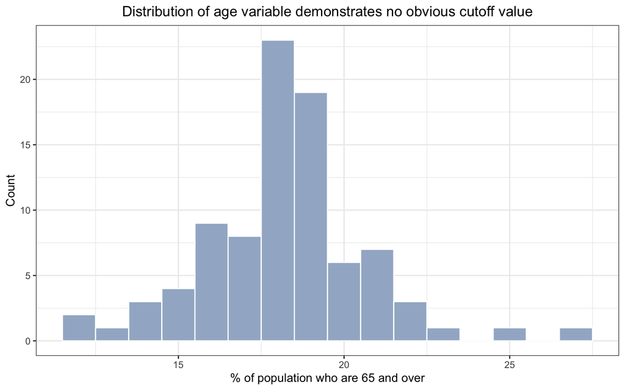

```r
g <- ggplot(q01, aes(x = age65plus)) +
  geom_histogram(fill = "lightsteelblue3", col = "white", binwidth = 1) +
  labs(x = "% of population who are 65 and over", y = "Count",
       title = "Distribution of age variable demonstrates no obvious cutoff value") +
  theme_bw() +
  theme(plot.title = element_text(hjust = 0.5))

g
```

```r
q01 <- q01 %>%
  mutate(age65plus_fct =
           case_when(age65plus < median(age65plus) ~ "Younger Community",
                     age65plus >= median(age65plus) ~ "Older Community")) %>%
  mutate(age65plus_fct = factor(age65plus_fct, levels = c("Younger Community", "Older Community")))
```

Finally, we’ll produce our visualization using `ggplot`, comparing `food_env` and `unemployed` with as scatter plots faceted by the `age65plus_fct` variable.

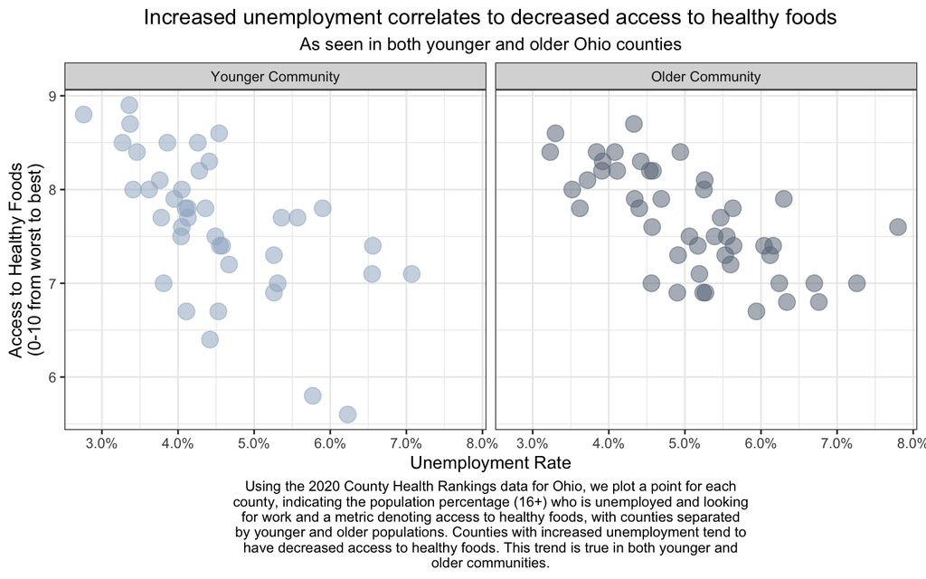

```r
caption_wrap <- str_wrap("Using the 2020 County Health Rankings data for Ohio, we plot a point for each county, indicating the population percentage (16+) who is unemployed and looking for work and a metric denoting access to healthy foods, with counties separated by younger and older populations. Counties with increased unemployment tend to have decreased access to healthy foods. This trend is true in both younger and older communities.")

g2 <- ggplot(q01, aes(x = unemployed, y = food_env, color = age65plus_fct)) +
  geom_point(aes(size = 4, alpha = 0.5), show.legend = FALSE) +
  facet_wrap(~age65plus_fct) +
  labs(x = "Unemployment Rate",
       y = "Access to Healthy Foods\n(0-10 from worst to best)",
       title = "Increased unemployment correlates to decreased access to healthy foods",
       subtitle = "As seen in both younger and older Ohio counties",
       caption = caption_wrap) +
  scale_x_continuous(labels = percent_format(scale = 1)) +
  scale_color_manual(values = c("lightsteelblue3", "lightsteelblue4")) +
  theme_bw() +
  theme(plot.title = element_text(hjust = 0.5),
        plot.subtitle = element_text(hjust = 0.5),
        plot.caption = element_text(hjust = 0.5))

g2
```

# 2 Question 2

Identify an important thing that you learned about prediction from your reading of Nate Silver’s The Signal and the Noise either in Chapter 2 (about political predictions) or in chapters 3 (baseball), 4 (weather) or 5 (earthquakes). What does this thing you learned suggest to you about the way you build prediction models, and how can you adopt this new way of thinking to improve the models you’ll generate in this Lab and elsewhere in your scientific life?

Write a short essay (between 150 and 250 words is appropriate) using clearly constructed and complete sentences to respond to this. The essay should be composed using R Markdown.

- We encourage you to provide brief citations or quotes from Silver and elsewhere as needed.
- In citing The Signal and the Noise a quotation with (Silver, Chapter X) is sufficient.
- In citing another work, a more detailed citation is appropriate. Citations and quotations do not count towards the suggested word limit.

# 3 Question 3

In this question, we’ll create a linear regression model to assess the impact of food availability on obesity rates in a county, taking into account median income. To start, we’ll first extract these variables of interest, check for missing values, and then assess each variable’s distribution using a histogram.

```r
q03 <- oh20 %>%
  select(fips, county, obese_pct, food_env, median_income)

miss_case_table(q03)
```

|  | n_miss_in_case | n_cases | pct_cases |
| --- | --- | --- | --- |
| 1 | 0 | 88 | 100 |

As we can see there are no missing values, so we’ll move forward with plotting the distribution of each variable. As we see below, none of the variables are egregiously non-normal, so we will move forward without transforming any of them.

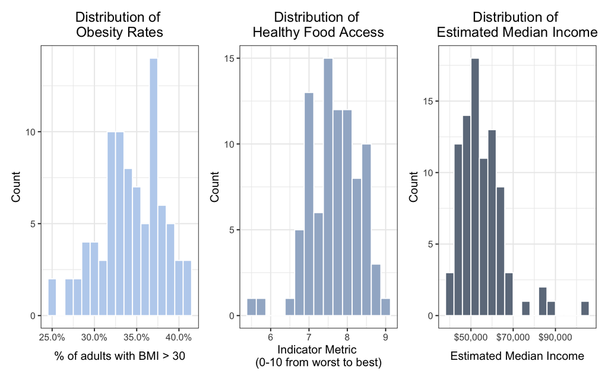

```r
g_obese_pct <- ggplot(q03, aes(x = obese_pct)) +
  geom_histogram(fill = "lightsteelblue2", col = "white", binwidth = 1) +
  labs(x = "% of adults with BMI > 30", y = "Count",
       title = "Distribution of \nObesity Rates") +
  scale_x_continuous(labels = percent_format(scale = 1)) +
  theme_bw() +
  theme(plot.title = element_text(hjust = 0.5))

g_food_env <- ggplot(q03, aes(x = food_env)) +
  geom_histogram(fill = "lightsteelblue3", col = "white", binwidth = 0.25) +
  labs(x = "Indicator Metric \n(0-10 from worst to best)", y = "Count",
       title = "Distribution of \nHealthy Food Access") +
  theme_bw() +
  theme(plot.title = element_text(hjust = 0.5))

g_median_income <- ggplot(q03, aes(x = median_income)) +
  geom_histogram(fill = "lightsteelblue4", col = "white", binwidth = 4000) +
  labs(x = "Estimated Median Income", y = "Count",
       title = "Distribution of \nEstimated Median Income") +
  scale_x_continuous(labels = dollar_format()) +
  theme_bw() +
  theme(plot.title = element_text(hjust = 0.5))


g_obese_pct + g_food_env + g_median_income
```

Finally, we’ll produce our linear regression model with `obese_pct` as our outcome variable and `food_env` as our predictor variable, adjusting for `median_income`. In this model, we see that the predicted percentage of adults with a BMI over 30 increases by 1.40% for every unit increase in the `food_env` metric. We are 90% confident that this predicted increase falls between 0.27% and 2.53%.

```r
m1_q03 <- lm(obese_pct ~ food_env + median_income, q03)

tidy(m1_q03, conf.int = TRUE, conf.level = 0.90) %>%
    select(term, estimate,
           low90 = conf.low, high90 = conf.high,
           se = std.error, p = p.value) %>%
    kable(digits = c(0,5,5,5,5,5))
```

| term | estimate | low90 | high90 | se | p |
| --- | --- | --- | --- | --- | --- |
| (Intercept) | 36.32615 | 29.49863 | 43.15367 | 4.10560 | 0.00000 |
| food_env | 1.40471 | 0.27713 | 2.53230 | 0.67805 | 0.04133 |
| median_income | -0.00023 | -0.00030 | -0.00016 | 0.00004 | 0.00000 |

# 4 Question 4

Evaluate the quality of the model you fit in Question 3 in terms of adherence to regression modeling assumptions, through the specification and written evaluation of residual plots. What might be done to improve the fit of the model you’ve developed in Question 3? Identify by name any outlying counties and explain why they are flagged as outliers.

Next, we’ll examine the residual plots for the model produced in Question 3, `m1_q03`.

Based on the plots below, our model adheres to the principles of regression modeling assumptions well. The Residuals vs. Fitted plot does not have any obvious pattern or bend to the curve, indicating acceptably constant variance. Similarly, the Scale-Location plot does not indicate non-constant variance, as the loess smooth curve is relatively flat. The Residuals vs. Fitted plot shows us that the counties from rows 43, 46, and 68 are the biggest outliers in the data, as they have the three largest residuals. However, based on the Residuals vs. Leverage plot, they aren’t influencing the model very much. Additionally, the Normal Q-Q plot does not demonstrate substantial non-normality.

Finally, to improve this model, we could remove these outlying counties, although their lack of influence on the model likely means it will not effect the model greatly. We will identify the names of these counties below.

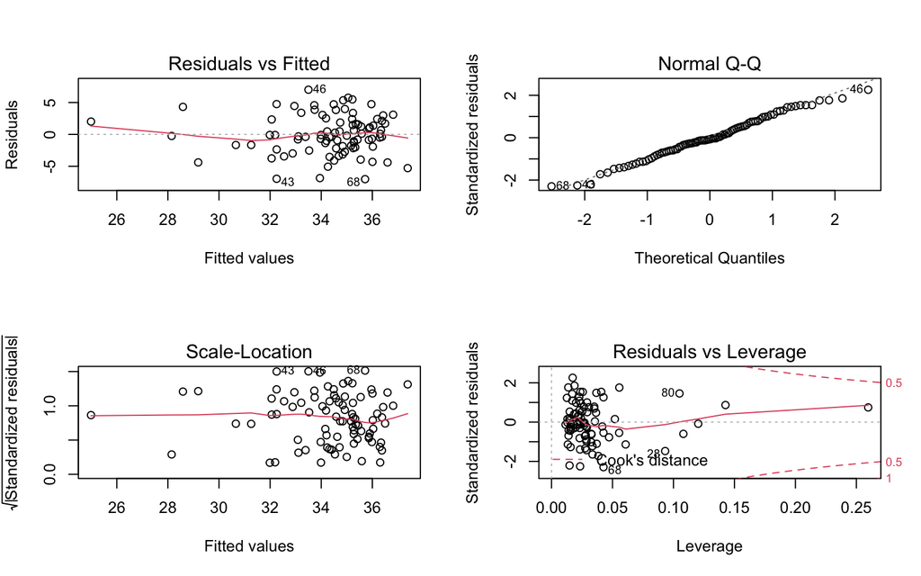

```r
par(mfrow = c(2,2))
plot(m1_q03)
```

```r
par(mfrow = c(1,1))
```

Here, we’ll use the `slice` function to identify the greatest outliers based on the row numbers identified in the Residuals vs. Fitted plot. Those counties are Lake, Logan, and Preble county. Based on the plot Logan County (row 46) was under-predicted by our model, while Lake County and Preble County were over-predicted by our model.

```r
slice(q03, c(43, 46, 68))
```

| fips | county | obese_pct | food_env | median_income |
| --- | --- | --- | --- | --- |
| 39085 | Lake | 25.3 | 7.9 | 65883 |
| 39091 | Logan | 40.5 | 8.1 | 61699 |
| 39135 | Preble | 28.7 | 8.4 | 53904 |

# 5 Question 5

Create a logistic regression model to predict the presence of a water violation (as contained in h2oviol) on the basis of sev_housing and pm2.5. Specify and then carefully interpret the estimated odds ratio associated with the sev_housing effect and a 90% uncertainty interval around that estimate in context using nothing but complete English sentences. Use a model with main effects only.